# Framing effect analysis

# 7 H3

H3: Alexithymia is negatively associated with framing effects (i.e., higher levels of emotional awareness make participants more inclined to respond to the framed situations and hence more susceptible to framing effects.

```r
fit <- df_framing_l %>%
  left_join(df_inddiff) %>%
  glmer(choice ~ paq*frame + (1|id) + (1|vignette) ,family = "binomial", .)
summary(fit)
```

```
## Generalized linear mixed model fit by maximum likelihood (Laplace
##   Approximation) [glmerMod]
##  Family: binomial  ( logit )
## Formula: choice ~ paq * frame + (1 | id) + (1 | vignette)
##    Data: .
##
##      AIC      BIC   logLik deviance df.resid
##   4184.9   4221.8  -2086.5   4172.9     3431
##
## Scaled residuals:
##     Min      1Q  Median      3Q     Max
## -2.9631 -0.6470  0.3375  0.6173  2.3110
##
## Random effects:
##  Groups   Name        Variance Std.Dev.
##  id       (Intercept) 1.8219   1.3498
##  vignette (Intercept) 0.2523   0.5023
## Number of obs: 3437, groups:  id, 1156; vignette, 3
##
## Fixed effects:
##               Estimate Std. Error z value Pr(>|z|)
## (Intercept)   -0.77864    0.37102  -2.099   0.0358 *
## paq            0.14723    0.07508   1.961   0.0499 *
## frameloss      1.95753    0.29971   6.531 6.51e-11 ***
## paq:frameloss -0.16159    0.09648  -1.675   0.0940 .
## ---
## Signif. codes:  0 '***' 0.001 '**' 0.01 '*' 0.05 '.' 0.1 ' ' 1
##
## Correlation of Fixed Effects:
##             (Intr) paq    frmlss
## paq         -0.591
## frameloss   -0.378  0.570
## paq:framlss  0.355 -0.599 -0.942
```

```
## Data were 'prettified'. Consider using `terms="paq [all]"` to get smooth plots.
```

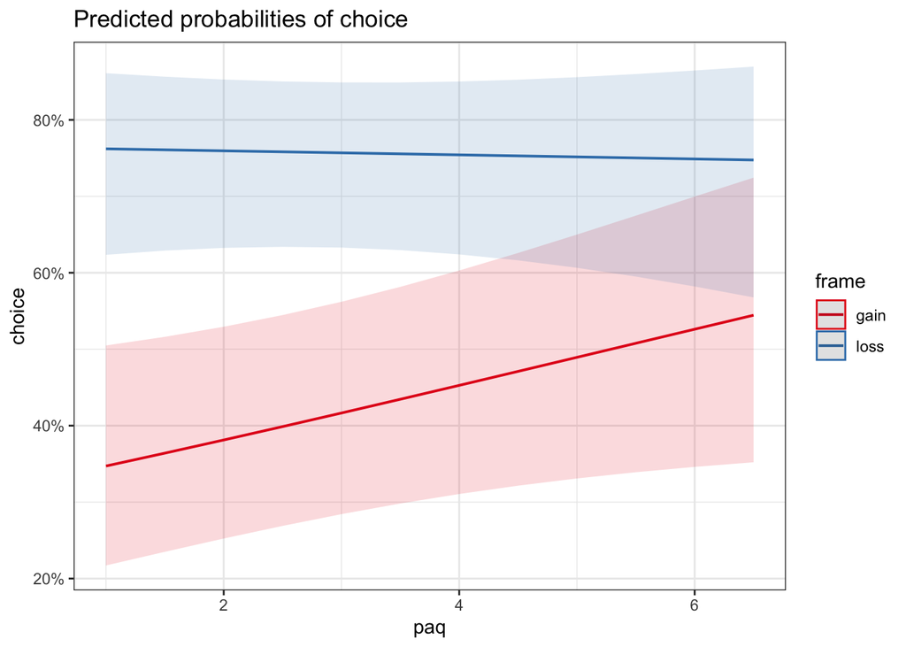

```r
plot_model(fit, type = "int", terms="paq [all]")
```

> Marginally signifciant support

# 8 Secondary analyses

Frame x key issue

```r
fit <- df_framing_l %>%
  mutate_at(vars(frame, vignette), as.factor) %>%
  glm(choice ~ frame*keyIssue,family = "binomial", .)
summary(fit)
```

```
##
## Call:
## glm(formula = choice ~ frame * keyIssue, family = "binomial",
##     data = .)
##
## Deviance Residuals:
##     Min       1Q   Median       3Q      Max
## -1.6169  -1.0729   0.8523   0.8523   1.3310
##
## Coefficients:
##                    Estimate Std. Error z value Pr(>|z|)
## (Intercept)        -0.25087    0.04856  -5.166 2.39e-07 ***
## frameloss           1.07648    0.07136  15.086  < 2e-16 ***
## keyIssue           -0.10330    0.21190  -0.487    0.626
## frameloss:keyIssue  0.26933    0.32748   0.822    0.411
## ---
## Signif. codes:  0 '***' 0.001 '**' 0.01 '*' 0.05 '.' 0.1 ' ' 1
##
## (Dispersion parameter for binomial family taken to be 1)
##
##     Null deviance: 4970.9  on 3631  degrees of freedom
## Residual deviance: 4715.6  on 3628  degrees of freedom
## AIC: 4723.6
##
## Number of Fisher Scoring iterations: 4
```

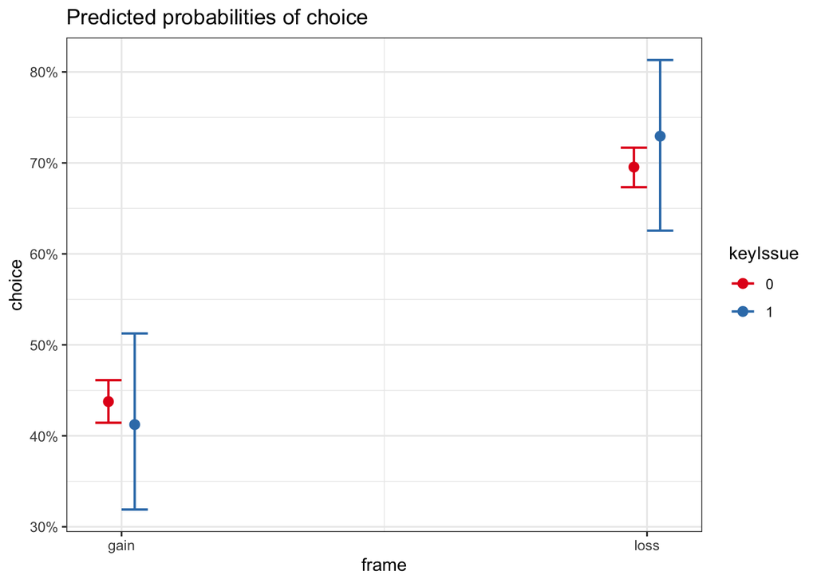

```r
plot_model(fit, type = "int")
```

> The data are trending in the direction that if the vignette refers to what politicians see as a key issue, then the framing effect is bigger. However, this is not even close to significance.

Frame x key issue (no dpecon)

```r
fit <- df_framing_l %>%
  mutate_at(vars(frame, vignette), as.factor) %>%
  filter(vignette != "dpecon") %>%
  glm(choice ~ frame*keyIssue,family = "binomial", .)
summary(fit)
```

```
##
## Call:
## glm(formula = choice ~ frame * keyIssue, family = "binomial",
##     data = .)
##
## Deviance Residuals:
##     Min       1Q   Median       3Q      Max
## -1.8340  -1.0460   0.7878   0.7878   1.5096
##
## Coefficients:
##                    Estimate Std. Error z value Pr(>|z|)
## (Intercept)        -0.31720    0.05827  -5.444 5.22e-08 ***
## frameloss           1.32824    0.08735  15.205  < 2e-16 ***
## keyIssue           -0.43657    0.30872  -1.414   0.1573
## frameloss:keyIssue  0.90144    0.50310   1.792   0.0732 .
## ---
## Signif. codes:  0 '***' 0.001 '**' 0.01 '*' 0.05 '.' 0.1 ' ' 1
##
## (Dispersion parameter for binomial family taken to be 1)
##
##     Null deviance: 3418.4  on 2507  degrees of freedom
## Residual deviance: 3148.8  on 2504  degrees of freedom
## AIC: 3156.8
##
## Number of Fisher Scoring iterations: 4
```

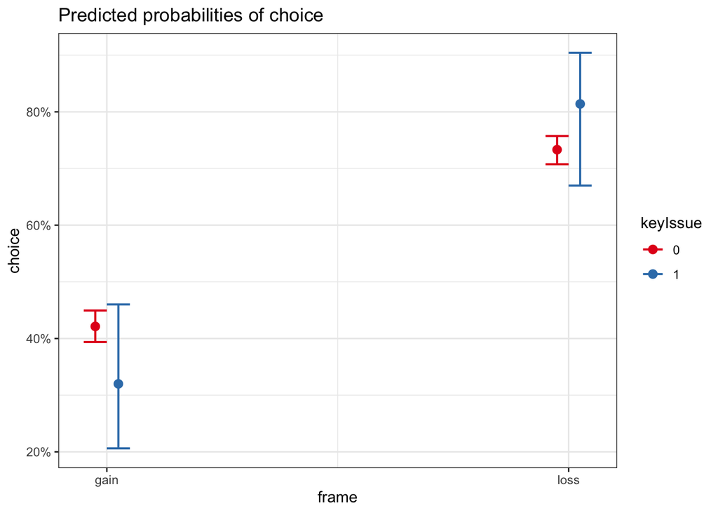

```r
plot_model(fit, type = "int")
```

Frame x vignette

```r
fit <- df_framing_l %>%
  mutate_at(vars(frame, vignette), as.factor) %>%
  glm(choice ~ frame*vignette,family = "binomial", .)
summary(fit)
```

```
##
## Call:
## glm(formula = choice ~ frame * vignette, family = "binomial",
##     data = .)
##
## Deviance Residuals:
##     Min       1Q   Median       3Q      Max
## -1.7234  -1.1413   0.7167   0.9938   1.6814
##
## Coefficients:
##                          Estimate Std. Error z value Pr(>|z|)
## (Intercept)              -1.13475    0.09263 -12.250  < 2e-16 ***
## frameloss                 1.97365    0.12728  15.507  < 2e-16 ***
## vignettedp                1.51362    0.12334  12.272  < 2e-16 ***
## vignettedpecon            1.04929    0.12535   8.371  < 2e-16 ***
## frameloss:vignettedp     -1.12420    0.17871  -6.291 3.16e-10 ***
## frameloss:vignettedpecon -1.43953    0.17553  -8.201 2.38e-16 ***
## ---
## Signif. codes:  0 '***' 0.001 '**' 0.01 '*' 0.05 '.' 0.1 ' ' 1
##
## (Dispersion parameter for binomial family taken to be 1)
##
##     Null deviance: 4970.9  on 3631  degrees of freedom
## Residual deviance: 4510.3  on 3626  degrees of freedom
## AIC: 4522.3
##
## Number of Fisher Scoring iterations: 4
```

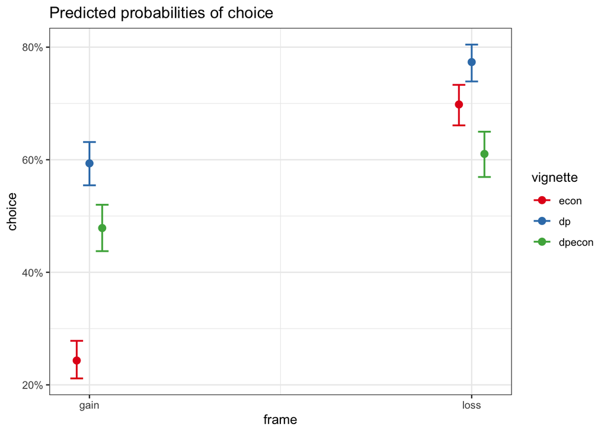

```r
plot_model(fit, type = "int")
```

> There is significantly less of a framing effect in conditions which involve data privacy than in conditions which involve jobs saved and lost. The econ condition looks similar to how the traditional Asian Disease Problem result from Kahneman and Tversky. I wonder whether people/politicians view a data privacy breach in terms of how many people’s information was unsecured or whether people think of privacy breaches simply in terms of whether or not it occurred. This may be different than something like jobs lost where the quantity of jobs lost is more salient. Also, given the previous findings, it might mean that people care less about data breaches than jobs lost which is why you see less framing effect.

Frame x age

```r
fit <- df_framing_l %>%
  left_join(df_inddiff) %>%
  mutate_at(vars(frame, vignette), as.factor) %>%
  glm(choice ~ frame*age, family = "binomial", .)
summary(fit)
```

```
##
## Call:
## glm(formula = choice ~ frame * age, family = "binomial", data = .)
##
## Deviance Residuals:
##     Min       1Q   Median       3Q      Max
## -1.6041  -1.0760   0.8299   0.8942   1.3344
##
## Coefficients:
##                Estimate Std. Error z value Pr(>|z|)
## (Intercept)   -0.131341   0.192273  -0.683    0.495
## frameloss      1.235983   0.283878   4.354 1.34e-05 ***
## age           -0.003390   0.004805  -0.705    0.481
## frameloss:age -0.004052   0.006976  -0.581    0.561
## ---
## Signif. codes:  0 '***' 0.001 '**' 0.01 '*' 0.05 '.' 0.1 ' ' 1
##
## (Dispersion parameter for binomial family taken to be 1)
##
##     Null deviance: 4352.0  on 3176  degrees of freedom
## Residual deviance: 4133.2  on 3173  degrees of freedom
##   (455 observations deleted due to missingness)
## AIC: 4141.2
##
## Number of Fisher Scoring iterations: 4
```

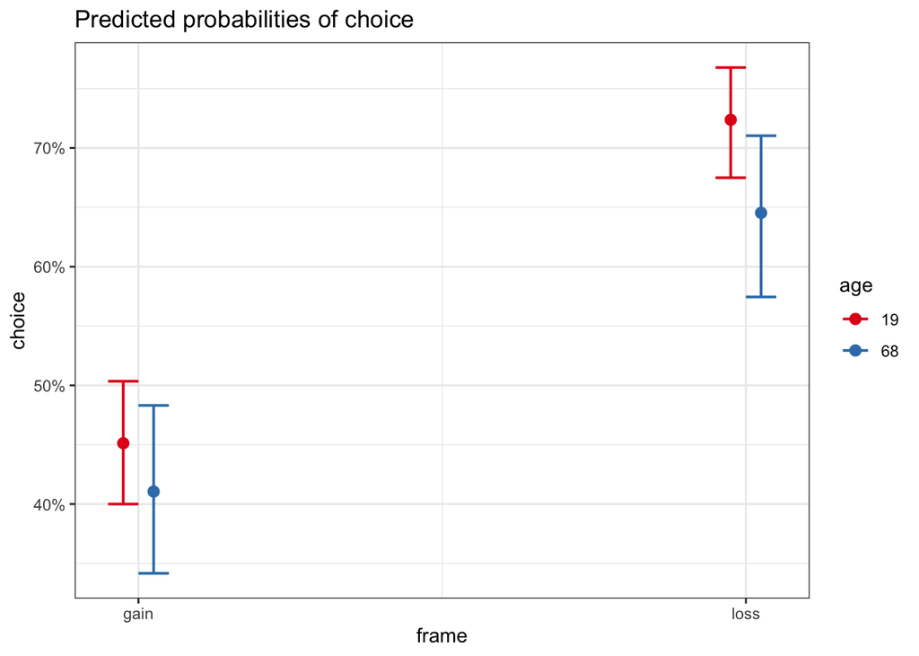

```r
plot_model(fit, type = "int")
```

Frame x gender

```r
fit <- df_framing_l %>%
  left_join(df_inddiff) %>%
  filter(gender == 0 | gender == 1) %>%
  mutate_at(vars(frame, vignette), as.factor) %>%
  glm(choice ~ frame*gender, family = "binomial", .)
summary(fit)
```

```
##
## Call:
## glm(formula = choice ~ frame * gender, family = "binomial", data = .)
##
## Deviance Residuals:
##     Min       1Q   Median       3Q      Max
## -1.5667  -1.0979   0.8329   0.8591   1.3312
##
## Coefficients:
##                   Estimate Std. Error z value Pr(>|z|)
## (Intercept)       -0.18984    0.06275  -3.025  0.00248 **
## frameloss          0.99647    0.09072  10.984  < 2e-16 ***
## gender1           -0.16476    0.09912  -1.662  0.09647 .
## frameloss:gender1  0.23848    0.14725   1.620  0.10532
## ---
## Signif. codes:  0 '***' 0.001 '**' 0.01 '*' 0.05 '.' 0.1 ' ' 1
##
## (Dispersion parameter for binomial family taken to be 1)
##
##     Null deviance: 4729.1  on 3455  degrees of freedom
## Residual deviance: 4483.4  on 3452  degrees of freedom
## AIC: 4491.4
##
## Number of Fisher Scoring iterations: 4
```

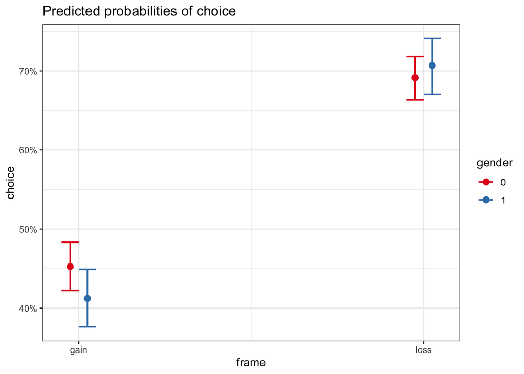

```r
plot_model(fit, type = "int")
```

> Trending towards larger framing effect for women, but not significant.

## 8.1 PAQ interactions

Three way interaction: PAQ x Frame x Vignette

```r
df_framing_l %>%
  left_join(df_inddiff) %>%
  group_by(id, paq, frame, vignette) %>%
  summarize(n = n()) %>%
  arrange(desc(n))
```

```
## # A tibble: 3,632 × 5
## # Groups:   id, paq, frame [2,147]
##       id   paq frame vignette     n
##    <dbl> <dbl> <chr> <fct>    <int>
##  1     3  4.71 gain  dp           1
##  2     3  4.71 loss  econ         1
##  3     3  4.71 loss  dpecon       1
##  4     4  3.14 gain  econ         1
##  5     4  3.14 gain  dp           1
##  6     4  3.14 gain  dpecon       1
##  7     9  1.71 gain  dp           1
##  8     9  1.71 gain  dpecon       1
##  9     9  1.71 loss  econ         1
## 10    13  2.43 gain  econ         1
## # … with 3,622 more rows
```

```r
fit <- df_framing_l %>%
  mutate_at(vars(frame, vignette), as.factor) %>%
  left_join(df_inddiff) %>%
  glm(choice ~ paq*frame*vignette,family = "binomial", .)
summary(fit)
```

```
##
## Call:
## glm(formula = choice ~ paq * frame * vignette, family = "binomial",
##     data = .)
##
## Deviance Residuals:
##     Min       1Q   Median       3Q      Max
## -1.7387  -1.1550   0.7154   1.0028   1.7155
##
## Coefficients:
##                                Estimate Std. Error z value Pr(>|z|)
## (Intercept)                  -1.2545031  0.3003554  -4.177 2.96e-05 ***
## paq                           0.0438485  0.0985062   0.445 0.656223
## frameloss                     2.0005278  0.4175872   4.791 1.66e-06 ***
## vignettedp                    1.4025918  0.4018433   3.490 0.000482 ***
## vignettedpecon                0.6110535  0.4026235   1.518 0.129095
## paq:frameloss                 0.0005835  0.1364029   0.004 0.996587
## paq:vignettedp                0.0209404  0.1321269   0.158 0.874073
## paq:vignettedpecon            0.1440123  0.1304973   1.104 0.269782
## frameloss:vignettedp         -0.8688074  0.5843982  -1.487 0.137102
## frameloss:vignettedpecon     -0.6338298  0.5670545  -1.118 0.263670
## paq:frameloss:vignettedp     -0.0829000  0.1908886  -0.434 0.664082
## paq:frameloss:vignettedpecon -0.2848803  0.1850391  -1.540 0.123666
## ---
## Signif. codes:  0 '***' 0.001 '**' 0.01 '*' 0.05 '.' 0.1 ' ' 1
##
## (Dispersion parameter for binomial family taken to be 1)
##
##     Null deviance: 4706.4  on 3436  degrees of freedom
## Residual deviance: 4268.1  on 3425  degrees of freedom
##   (195 observations deleted due to missingness)
## AIC: 4292.1
##
## Number of Fisher Scoring iterations: 4
```

```
## Data were 'prettified'. Consider using `terms="paq [all]"` to get smooth plots.
## Data were 'prettified'. Consider using `terms="paq [all]"` to get smooth plots.
## Data were 'prettified'. Consider using `terms="paq [all]"` to get smooth plots.
```

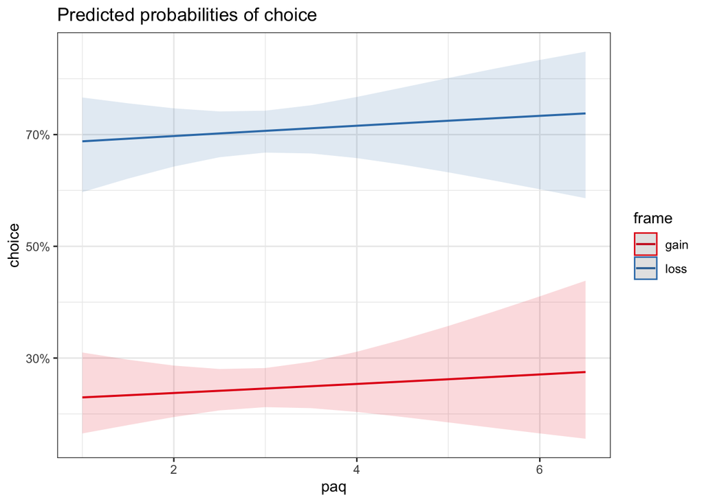

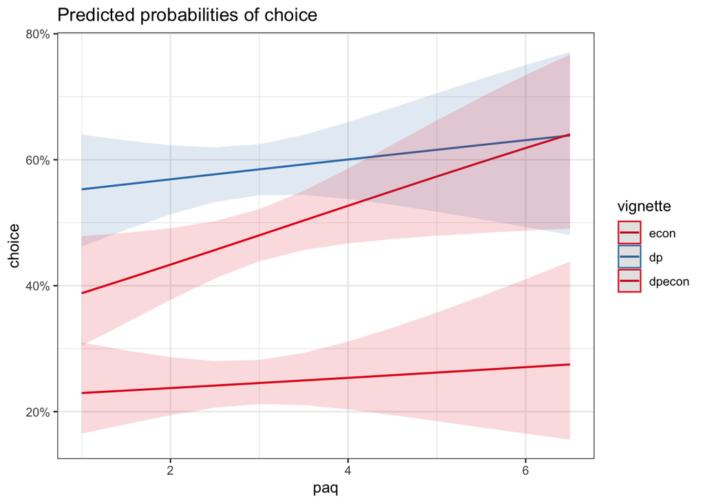

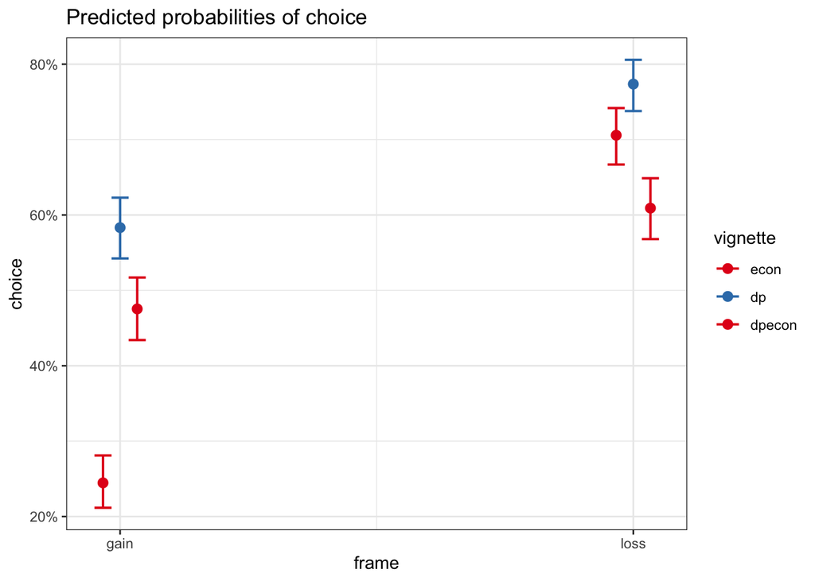

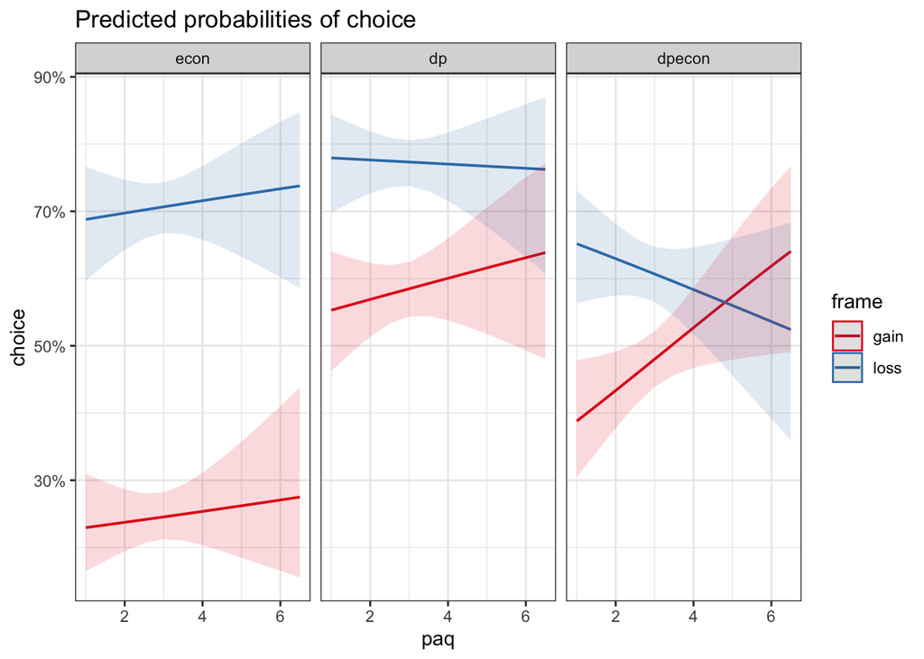

```r
plot_model(fit, type = "int", terms="paq [all]")
```

> No three-way interaction.

```r
fit <- df_framing_l %>%
  left_join(df_inddiff) %>%
  mutate_at(vars(paq, age), scale) %>%
  glmer(choice ~ paq*frame*age + (1|id) + (1|vignette) ,family = "binomial", .)
summary(fit)
```

```
## Generalized linear mixed model fit by maximum likelihood (Laplace
##   Approximation) [glmerMod]
##  Family: binomial  ( logit )
## Formula: choice ~ paq * frame * age + (1 | id) + (1 | vignette)
##    Data: .
##
##      AIC      BIC   logLik deviance df.resid
##   3828.6   3889.1  -1904.3   3808.6     3123
##
## Scaled residuals:
##     Min      1Q  Median      3Q     Max
## -2.8405 -0.6441  0.3299  0.6168  2.4676
##
## Random effects:
##  Groups   Name        Variance Std.Dev.
##  id       (Intercept) 1.918    1.3850
##  vignette (Intercept) 0.236    0.4858
## Number of obs: 3133, groups:  id, 1054; vignette, 3
##
## Fixed effects:
##                   Estimate Std. Error z value Pr(>|z|)
## (Intercept)       -0.37345    0.29149  -1.281   0.2001
## paq                0.17693    0.07969   2.220   0.0264 *
## frameloss          1.47032    0.10682  13.764   <2e-16 ***
## age               -0.13143    0.08030  -1.637   0.1017
## paq:frameloss     -0.22902    0.10145  -2.257   0.0240 *
## paq:age            0.09545    0.07832   1.219   0.2229
## frameloss:age      0.07775    0.10037   0.775   0.4385
## paq:frameloss:age  0.02498    0.10037   0.249   0.8035
## ---
## Signif. codes:  0 '***' 0.001 '**' 0.01 '*' 0.05 '.' 0.1 ' ' 1
##
## Correlation of Fixed Effects:
##             (Intr) paq    frmlss age    pq:frm paq:ag frmls:
## paq         -0.001
## frameloss   -0.165  0.028
## age          0.018 -0.133 -0.066
## paq:framlss  0.003 -0.597 -0.020  0.080
## paq:age     -0.036 -0.019  0.081 -0.049  0.006
## frameloss:g -0.015  0.081  0.027 -0.616 -0.110  0.039
## pq:frmlss:g  0.020  0.009 -0.095  0.036 -0.064 -0.584 -0.044
## optimizer (Nelder_Mead) convergence code: 0 (OK)
## Model failed to converge with max|grad| = 0.00532817 (tol = 0.002, component 1)
```

```
## Data were 'prettified'. Consider using `terms="paq [all]"` to get smooth plots.
## Data were 'prettified'. Consider using `terms="paq [all]"` to get smooth plots.
## Data were 'prettified'. Consider using `terms="paq [all]"` to get smooth plots.
```

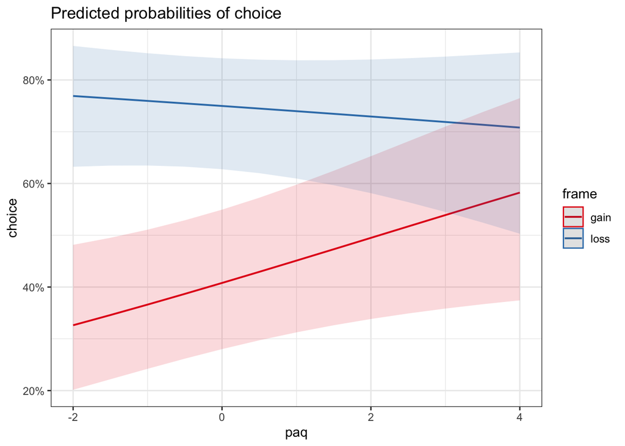

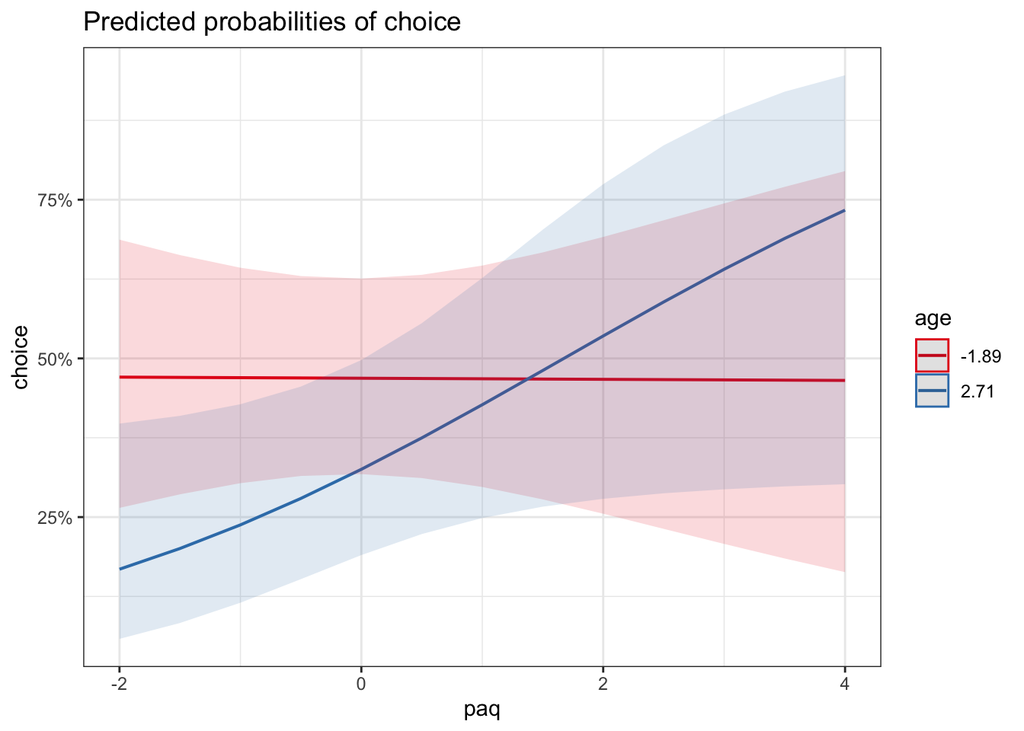

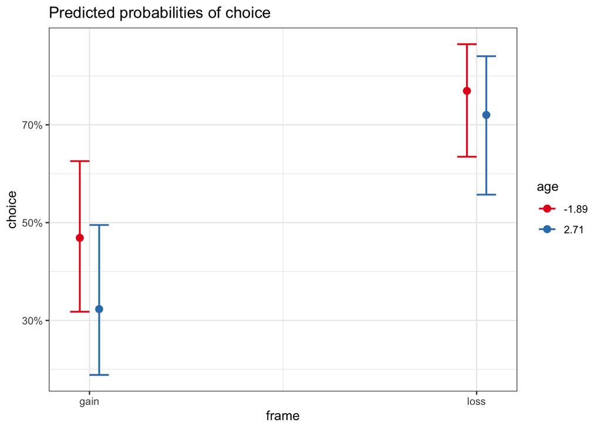

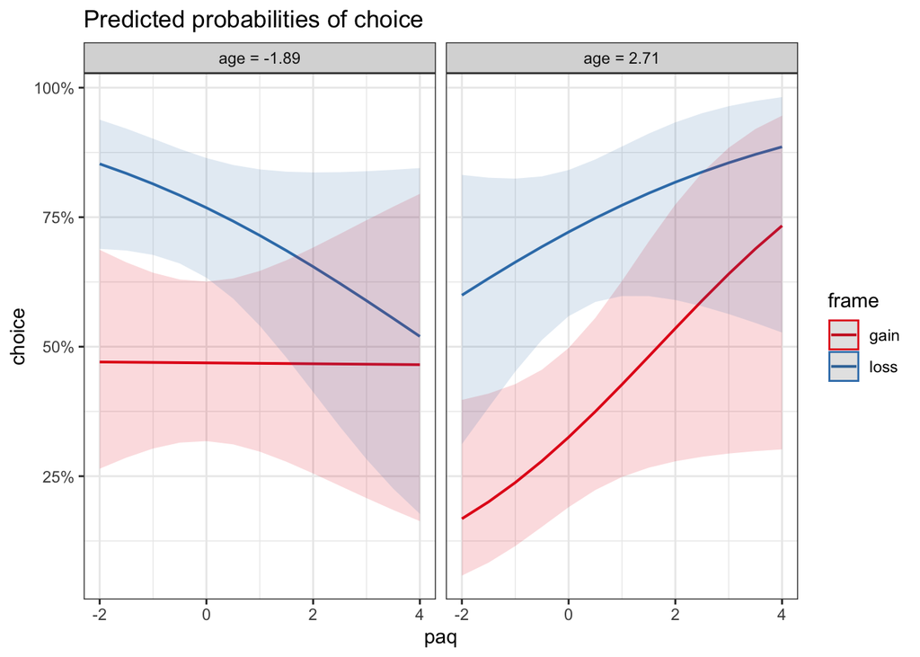

```r
plot_model(fit, type = "int", terms="paq [all]")
```

> no age moderation

```r
fit <- df_framing_l %>%
  left_join(df_inddiff) %>%
  mutate_at(vars(paq, age), scale) %>%
  glmer(choice ~ paq*frame*gender + (1|id) + (1|vignette) ,family = "binomial", .)
summary(fit)
```

```
## Generalized linear mixed model fit by maximum likelihood (Laplace
##   Approximation) [glmerMod]
##  Family: binomial  ( logit )
## Formula: choice ~ paq * frame * gender + (1 | id) + (1 | vignette)
##    Data: .
##
##      AIC      BIC   logLik deviance df.resid
##   4191.6   4302.1  -2077.8   4155.6     3419
##
## Scaled residuals:
##     Min      1Q  Median      3Q     Max
## -2.8100 -0.6468  0.3323  0.6112  2.2342
##
## Random effects:
##  Groups   Name        Variance Std.Dev.
##  id       (Intercept) 1.8184   1.3485
##  vignette (Intercept) 0.2489   0.4989
## Number of obs: 3437, groups:  id, 1156; vignette, 3
##
## Fixed effects:
##                         Estimate Std. Error z value Pr(>|z|)
## (Intercept)             -0.29834    0.30294  -0.985   0.3247
## paq                      0.20685    0.09267   2.232   0.0256 *
## frameloss                1.37599    0.11713  11.747   <2e-16 ***
## gender1                 -0.19426    0.15162  -1.281   0.2001
## gender2                 -2.72014    2.51428  -1.082   0.2793
## gender3                 -1.68064    2.02793  -0.829   0.4072
## paq:frameloss           -0.15560    0.11644  -1.336   0.1814
## paq:gender1             -0.23485    0.15095  -1.556   0.1198
## paq:gender2              0.61139    2.33074   0.262   0.7931
## paq:gender3              2.20666    2.43677   0.906   0.3652
## frameloss:gender1        0.28181    0.19506   1.445   0.1485
## frameloss:gender2       -2.88023  103.82172  -0.028   0.9779
## frameloss:gender3       16.71153 1024.52016   0.016   0.9870
## paq:frameloss:gender1    0.09855    0.19415   0.508   0.6117
## paq:frameloss:gender2    9.30840  191.75891   0.049   0.9613
## paq:frameloss:gender3  -11.89499 1242.14350  -0.010   0.9924
## ---
## Signif. codes:  0 '***' 0.001 '**' 0.01 '*' 0.05 '.' 0.1 ' ' 1
```

```
##
## Correlation matrix not shown by default, as p = 16 > 12.
## Use print(x, correlation=TRUE)  or
##     vcov(x)        if you need it
```

```
## optimizer (Nelder_Mead) convergence code: 0 (OK)
## unable to evaluate scaled gradient
## Model failed to converge: degenerate  Hessian with 2 negative eigenvalues
```

```
## Data were 'prettified'. Consider using `terms="paq [all]"` to get smooth plots.
## Data were 'prettified'. Consider using `terms="paq [all]"` to get smooth plots.
## Data were 'prettified'. Consider using `terms="paq [all]"` to get smooth plots.
```

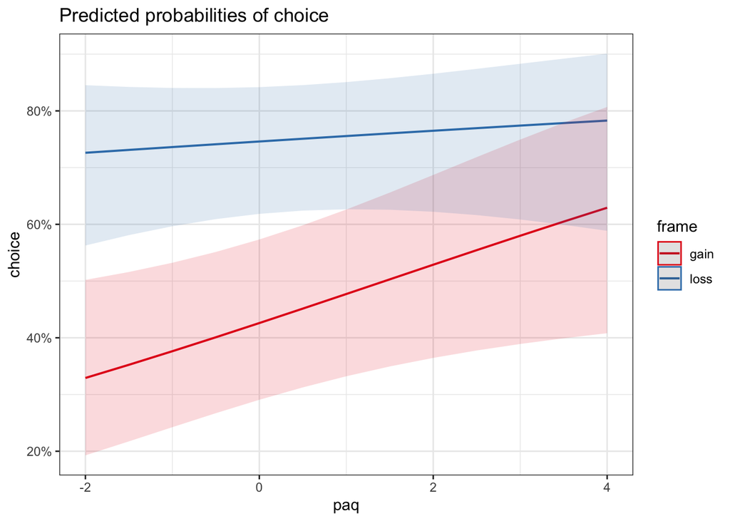

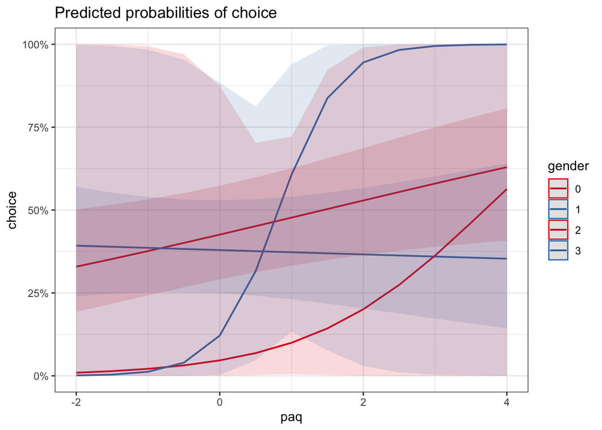

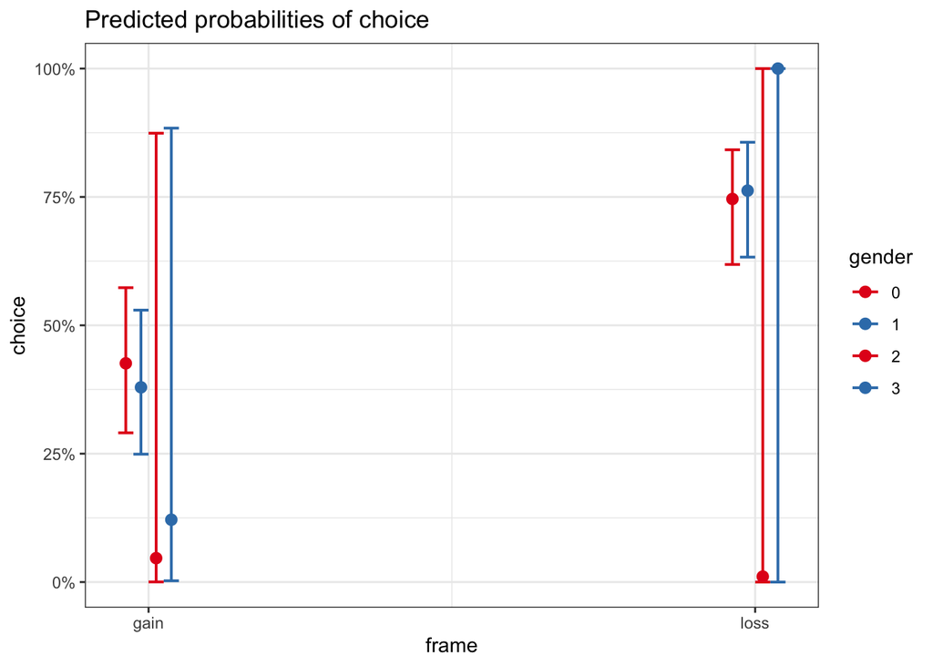

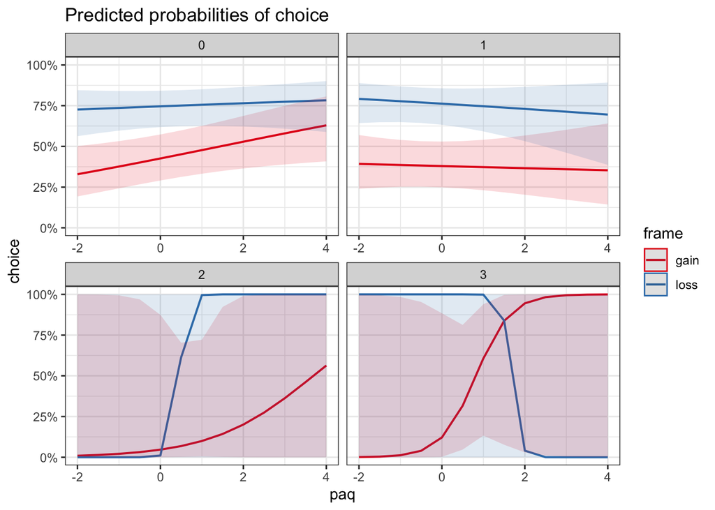

```r
plot_model(fit, type = "int", terms="paq [all]")
```

> no gender three way moderation

Frame x key issue x PAQ (no dpecon)

```r
fit <- df_framing_l %>%
  left_join(df_inddiff) %>%
  filter(vignette != "dpecon") %>%
  glm(choice ~ frame*keyIssue*paq,family = "binomial", .)
summary(fit)
```

```
##
## Call:
## glm(formula = choice ~ frame * keyIssue * paq, family = "binomial",
##     data = .)
##
## Deviance Residuals:
##     Min       1Q   Median       3Q      Max
## -2.0223  -1.0369   0.7797   0.7806   1.7983
##
## Coefficients:
##                         Estimate Std. Error z value Pr(>|z|)
## (Intercept)            -0.455033   0.192322  -2.366    0.018 *
## frameloss               1.484387   0.287593   5.161 2.45e-07 ***
## keyIssue               -1.305016   0.910593  -1.433    0.152
## paq                     0.038380   0.063275   0.607    0.544
## frameloss:keyIssue      0.714728   1.604639   0.445    0.656
## frameloss:paq          -0.036944   0.094011  -0.393    0.694
## keyIssue:paq            0.326014   0.285689   1.141    0.254
## frameloss:keyIssue:paq  0.003881   0.513644   0.008    0.994
## ---
## Signif. codes:  0 '***' 0.001 '**' 0.01 '*' 0.05 '.' 0.1 ' ' 1
##
## (Dispersion parameter for binomial family taken to be 1)
##
##     Null deviance: 3154.2  on 2312  degrees of freedom
## Residual deviance: 2887.6  on 2305  degrees of freedom
##   (195 observations deleted due to missingness)
## AIC: 2903.6
##
## Number of Fisher Scoring iterations: 4
```

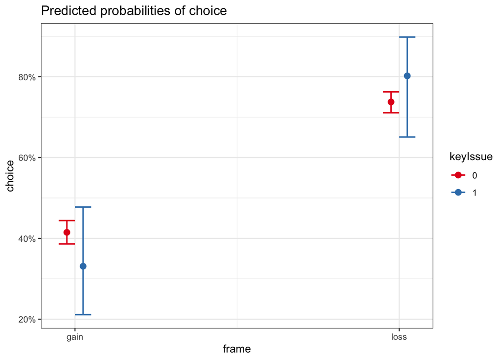

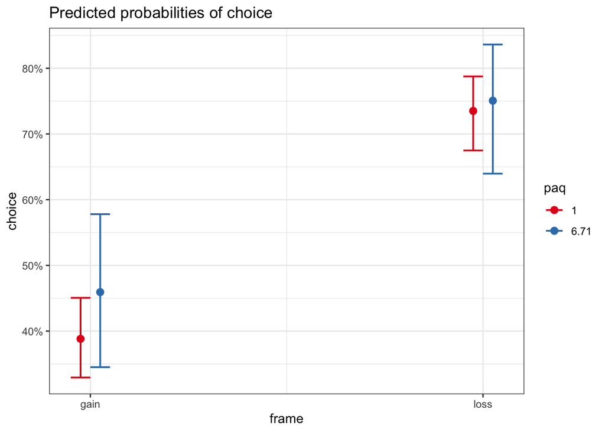

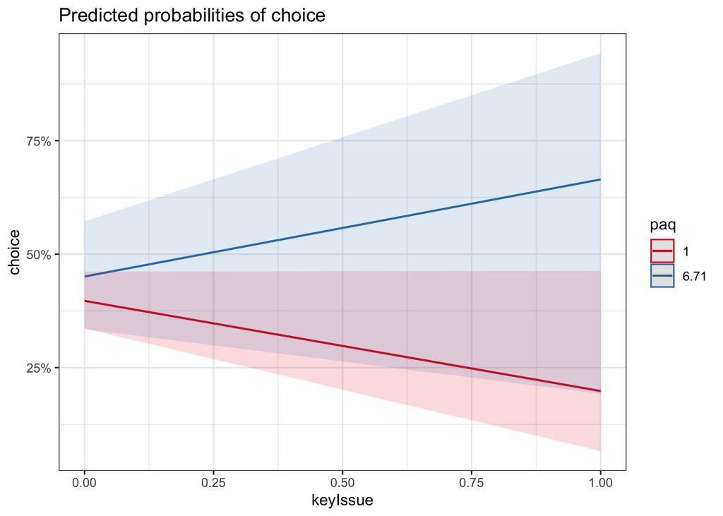

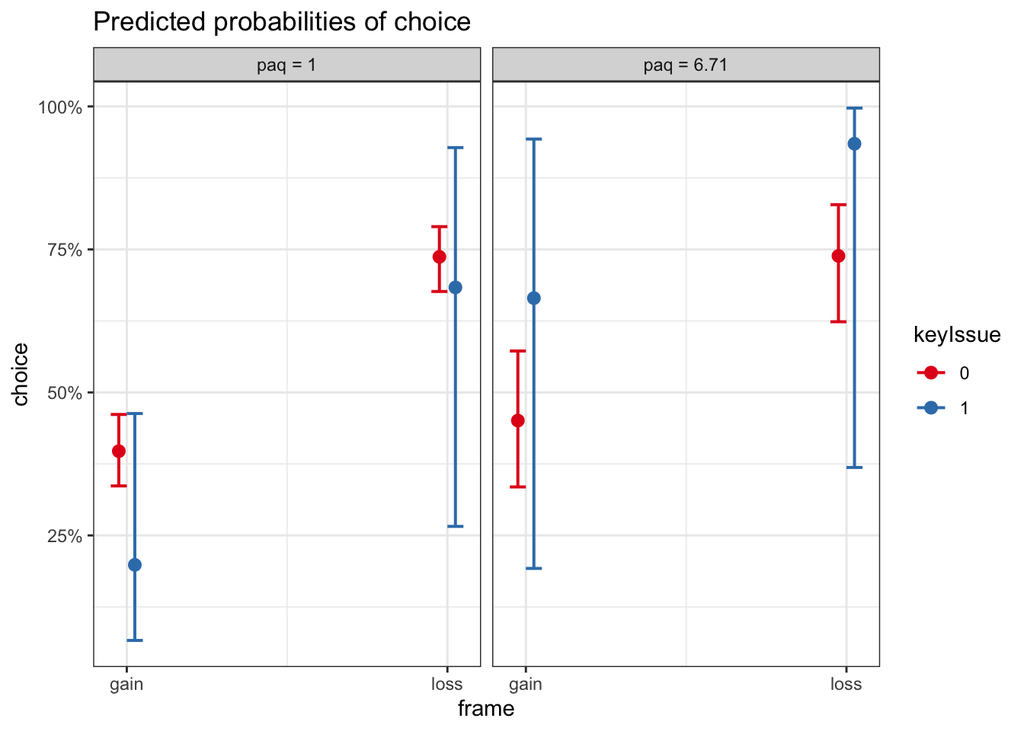

```r
plot_model(fit, type = "int")
```

> No three way interaction with whether it’s a key issue. Frankly, there’s just not enough power for this anyway.